# Homework 04

Xu,Junchao jux16@pitt.edu

today

# Overview

> In this assignment, You will use two datasets: the DJI(Dow Jones Index) data of stock price, and the political book co-purchase dataset for this assignment.

**Problem 1**. analyze the data of stock price: DJI.csv (included in the repository). The dataset contains historical price of stocks. Each column of the dataset is a stock and their code name is on the first row. The objective of the analysis is to group stocks together if they have similar trends in price.

1. Use PCA to reduce the dimension of stock-price information. Generate a scree plot and determine the number of principle components based on this plot. Plot the loadings for first principal component.  
   **hint:** Standardize the data before doing PCA. Specifically, make the stocks to be the unit (rows) of analysis, and standardize it for columns to be in the same scale, using `t` and `scale` in R. You will loose 2 points if you directly perform PCA without standardize the data.
2. Generate a scatter plot to that shows the projected stock prices (labeled with stock codes) on the first two principal components as x- and y-axes.
3. Generate an MDS map to plot stocks on a two-dimensional space.
4. Use k-means and hierarchical clustering to group stocks. Specifically, you will generate 8 MDS maps for the stocks and color the stocks based on different clustering methods: k-means with different number of clusters(k=4, k=8), h-clustering with single-link using different number of clusters(k=4, k=8), h-clustering with complete-link using different number of clusters(k=4, k=8), h-clustering with average-link using different number of clusters(k=4, k=8). For each hierarchical clustering method, generate a dendrogram.

**Problem 2**. analyze “Books about US Politics” data. The objective is to identify and visualize the clustering patterns of political books’ co-purchase activities. The original data was compiled from an online bookseller on Amazon.com, by V. Krebs [link](http://www.orgnet.com/divided.html).You will use two files of processed data for this task:

**bookinfo.csv** (included in the repository): contains the name and class for each book. Books have been given values 1, 2, or 3 to indicate whether they are “liberal”, “neutral”, or “conservative” repectively. (Note: in this assignment, we only include “liberal” and “conservative” books here.)  
**bookcopurchase.csv** (included in the repository): shows whether two books were “co-purchased” by the same buyers (0: not purchased together; 1: purchased together)

1. Create a book-by-book distance matrix. Generate an MDS plot to project the books with their names on a two dimensional space. Use shapes or color to differentiate the books’ Class (liberal or conservative).
2. Use K-means and hierarchical clustering to group books with their names, and color the books on the MDS plots based on the clustering results (you will need to use k-means,h-clustering with single-link, h-clustering with complete-link, h-clustering with average-link and k=2)
3. Compare the clustering results with the Class labels and identify books in a certain class that are assigned to a seemly wrong cluster. Specifically, based on k-means results, which liberal books are clustered together with conservative books, and vice versa? And based on the three variance (single-link, complete-link, average-link), which liberal books are clustered together with conservative books, and vice versa? (Note: you can just identify 2-3 books, no need to list all of them)
4. Compute the purity and entropy for these clustering results with respect to the books’ class labels. You will need to generate a 2×4 table as follows:

| Measure/Method | k-means | hclust-single | hclust-complete | hclust-average |
| --- | --- | --- | --- | --- |
| purity |  |  |  |  |
| entropy |  |  |  |  |

5. Based on your observation on both measures and mis-classified members, choose two clustering methods that generate the most meaningful results and explain why.

# Problem 1:

1a. Data loading and standarization

```r
library(dplyr)
dji <- read.csv('DJI.csv')
df <- data.frame(dji)

#standarization
data <- t(data.matrix(df))
data<-scale(data)
```

Perform PCA

```r
dji.pca<-prcomp(data,center=TRUE,scale=TRUE)
summary(dji.pca)
```

```
## Importance of components:
##                            PC1     PC2     PC3     PC4     PC5     PC6     PC7
## Standard deviation     12.2263 0.48444 0.41483 0.17762 0.16129 0.09937 0.09102
## Proportion of Variance  0.9966 0.00156 0.00115 0.00021 0.00017 0.00007 0.00006
## Cumulative Proportion   0.9966 0.99811 0.99926 0.99947 0.99964 0.99971 0.99976
##                            PC8     PC9    PC10    PC11    PC12    PC13    PC14
## Standard deviation     0.07677 0.07151 0.06308 0.05593 0.05373 0.04914 0.04494
## Proportion of Variance 0.00004 0.00003 0.00003 0.00002 0.00002 0.00002 0.00001
## Cumulative Proportion  0.99980 0.99984 0.99986 0.99988 0.99990 0.99992 0.99993
##                           PC15    PC16    PC17    PC18    PC19    PC20    PC21
## Standard deviation     0.03973 0.03766 0.03456 0.03134 0.03051 0.02840 0.02719
## Proportion of Variance 0.00001 0.00001 0.00001 0.00001 0.00001 0.00001 0.00000
## Cumulative Proportion  0.99994 0.99995 0.99996 0.99997 0.99997 0.99998 0.99998
##                           PC22    PC23    PC24    PC25    PC26    PC27    PC28
## Standard deviation     0.02595 0.02032 0.01889 0.01639 0.01584 0.01159 0.01076
## Proportion of Variance 0.00000 0.00000 0.00000 0.00000 0.00000 0.00000 0.00000
## Cumulative Proportion  0.99999 0.99999 0.99999 1.00000 1.00000 1.00000 1.00000
##                            PC29     PC30
## Standard deviation     0.009995 5.43e-15
## Proportion of Variance 0.000000 0.00e+00
## Cumulative Proportion  1.000000 1.00e+00
```

Scree plot:

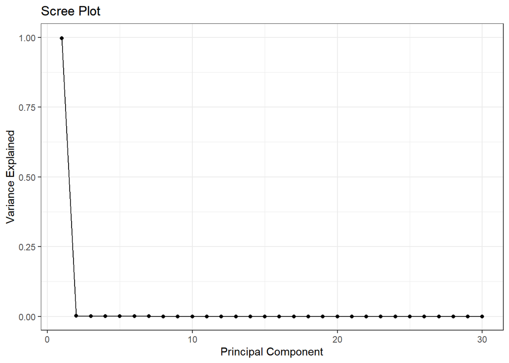

```r
library(ggplot2)
var_explained = dji.pca$sdev^2 / sum(dji.pca$sdev^2)
qplot(c(1:30), var_explained) +
  geom_line() +
  xlab("Principal Component") +
  ylab("Variance Explained") +
  ggtitle("Scree Plot") +
  ylim(0, 1)
```

As can be seen from the graph above, there is only one principal component.

Loadings of first principal component

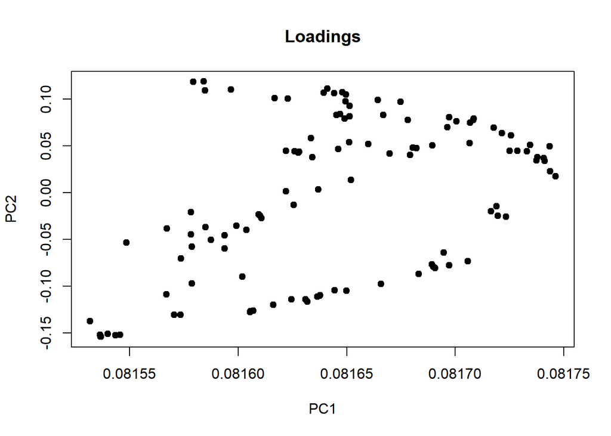

```r
PCAloadings <- dji.pca$rotation
plot(PCAloadings[,1:2],   # x and y data
     pch=21,              # point shape`
     bg="black",          # point color
     cex=1,               # point size
     main="Loadings"      # title of plot
)
```

1b.

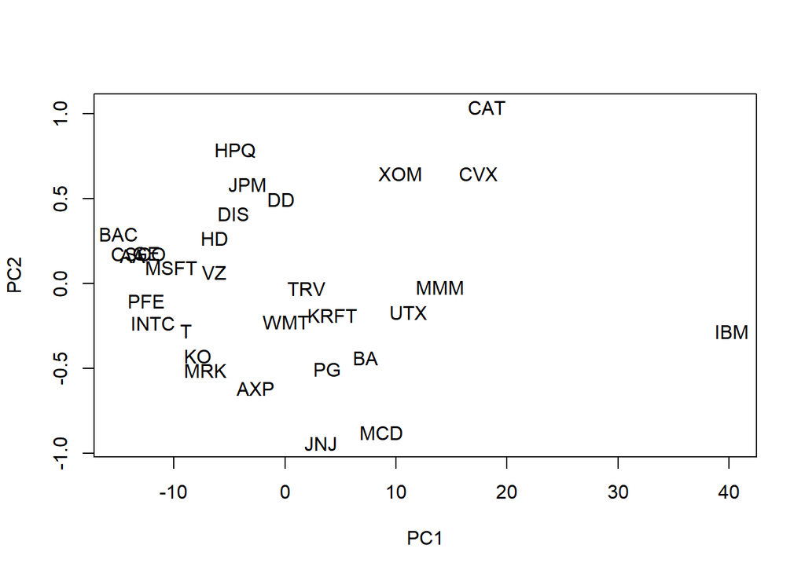

```r
data.pca = prcomp(data, scale=F)
data.pre = predict(data.pca)
plot(data.pre[,1:2], type="n")
text(x=data.pre[,1], y=data.pre[,2], labels=rownames(data))
```

1c.

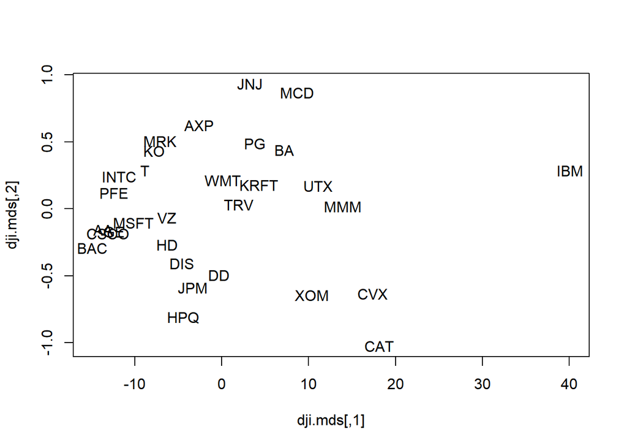

```r
dji.dist=dist(data[,-1])
dji.mds<-cmdscale(dji.dist)
plot(dji.mds,type='n')
text(dji.mds, labels=rownames(data))
```

d.

```r
library(ggpubr)
library(factoextra)
```

K-means:

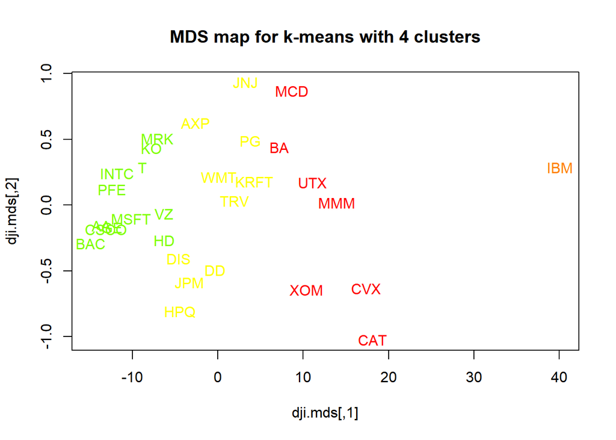

```r
set.seed(100)
dji.km=kmeans(data,centers=4,nstart=10)
cluster=dji.km$cluster
plot(dji.mds,type="n", main=paste0("MDS map for k-means with 4 clusters"))
text(dji.mds, rownames(data), col=rainbow(12)[cluster])
```

[figure not shown]

```r
set.seed(100)
dji.km=kmeans(data,centers=8,nstart=10)
cluster=dji.km$cluster
plot(dji.mds,type="n", main=paste0("MDS map for k-means with 4 clusters"))
text(dji.mds, rownames(data), col=rainbow(12)[cluster])
```

h-clustering with single-link:

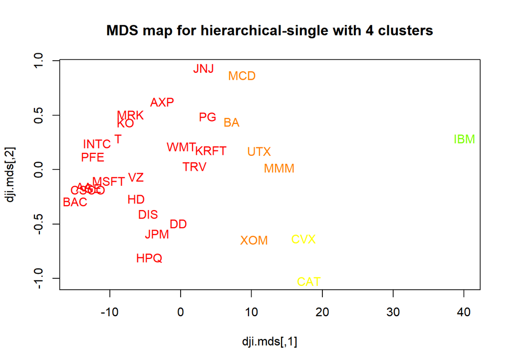

```r
dji.dist<-dist(data, method = 'euclidean')
dji.clust <- hclust(dji.dist, method = 'single')
hc1=cutree(dji.clust,4)
plot(dji.mds, type="n", main=paste0("MDS map for hierarchical-single with 4 clusters"))
text(dji.mds, rownames(dji.mds), col=rainbow(12)[hc1])
```

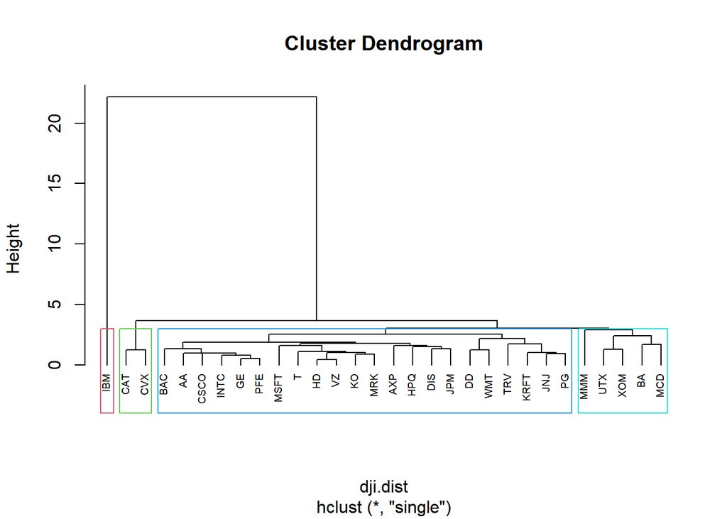

```r
plot(dji.clust,cex = 0.6, hang = -1)
rect.hclust(dji.clust, k = 4, border = 2:5)
```

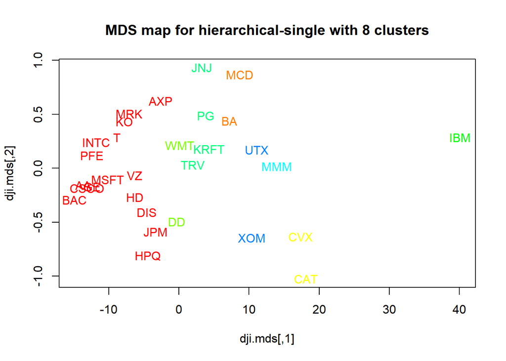

```r
dji.dist<-dist(data, method = 'euclidean')
dji.clust <- hclust(dji.dist, method = 'single')
hc2=cutree(dji.clust,8)
plot(dji.mds, type="n", main=paste0("MDS map for hierarchical-single with 8 clusters"))
text(dji.mds, rownames(dji.mds), col=rainbow(12)[hc2])
```

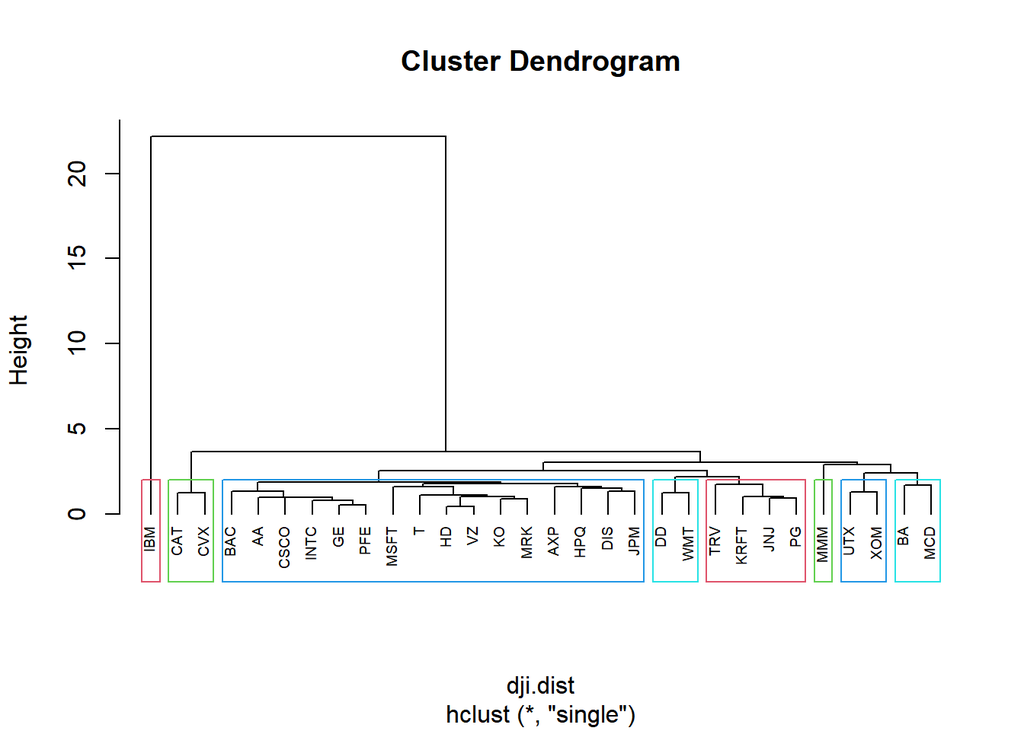

```r
plot(dji.clust,cex = 0.6, hang = -1)
rect.hclust(dji.clust, k = 8, border = 2:5)
```

h-clustering with complete-link:

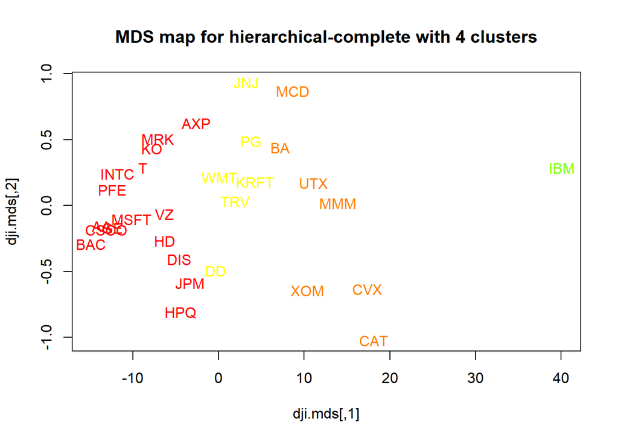

```r
dji.dist<-dist(data, method = 'euclidean')
dji.clust <- hclust(dji.dist, method = 'complete')
hc3=cutree(dji.clust,4)
plot(dji.mds, type="n", main=paste0("MDS map for hierarchical-complete with 4 clusters"))
text(dji.mds, rownames(dji.mds), col=rainbow(12)[hc3])
```

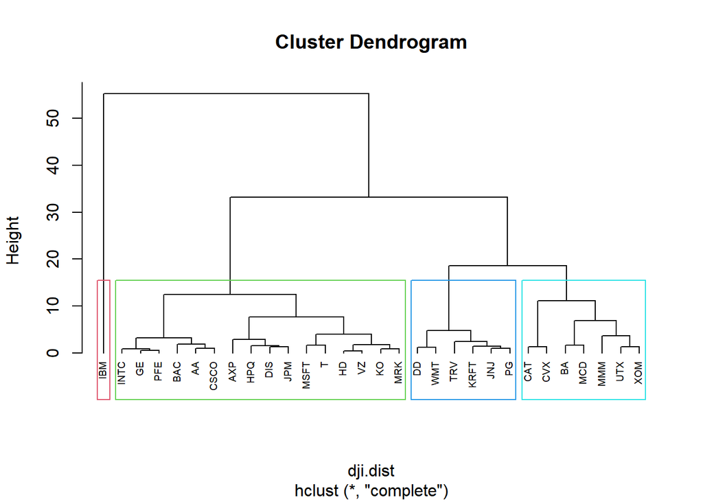

```r
plot(dji.clust,cex = 0.6, hang = -1)
rect.hclust(dji.clust, k = 4, border = 2:5)
```

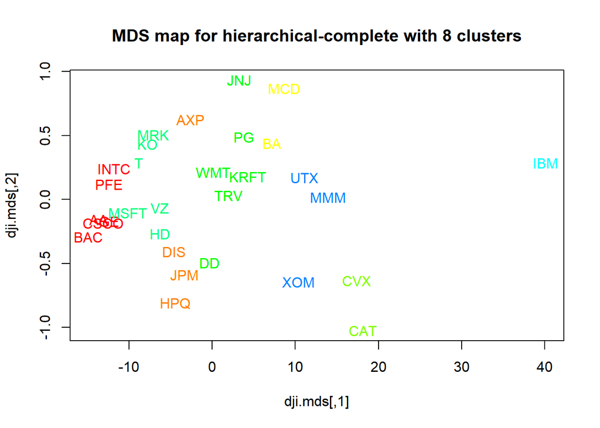

```r
dji.dist<-dist(data, method = 'euclidean')
dji.clust <- hclust(dji.dist, method = 'complete')
hc4=cutree(dji.clust,8)
plot(dji.mds, type="n", main=paste0("MDS map for hierarchical-complete with 8 clusters"))
text(dji.mds, rownames(dji.mds), col=rainbow(12)[hc4])
```

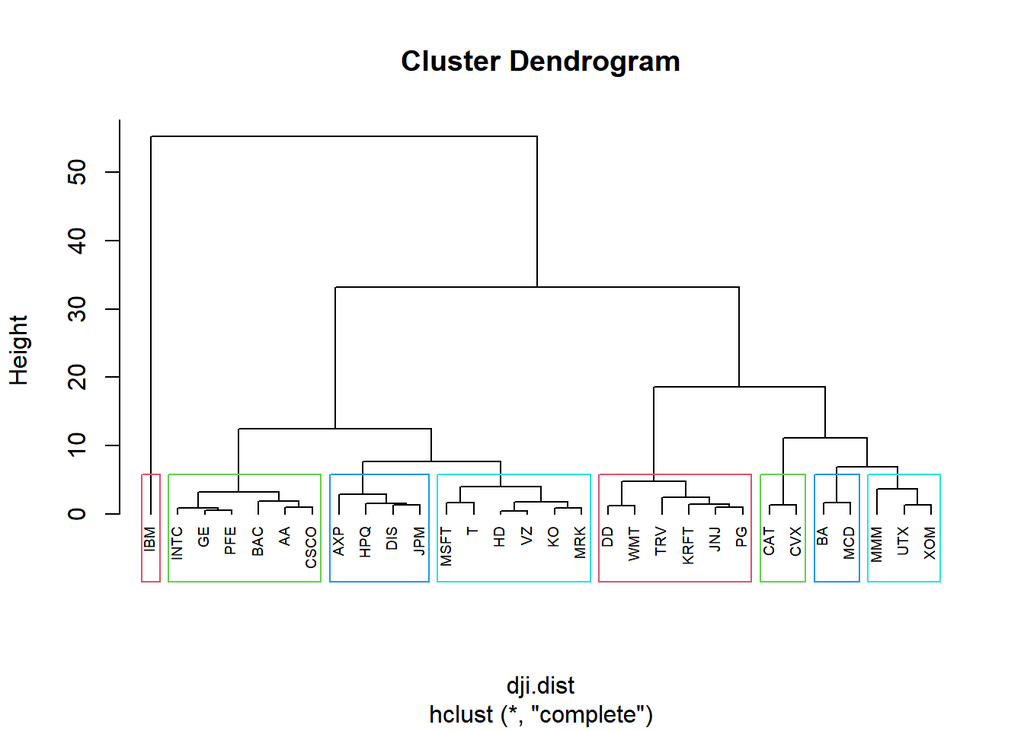

```r
plot(dji.clust,cex = 0.6, hang = -1)
rect.hclust(dji.clust, k = 8, border = 2:5)
```

h-clustering with average-link:

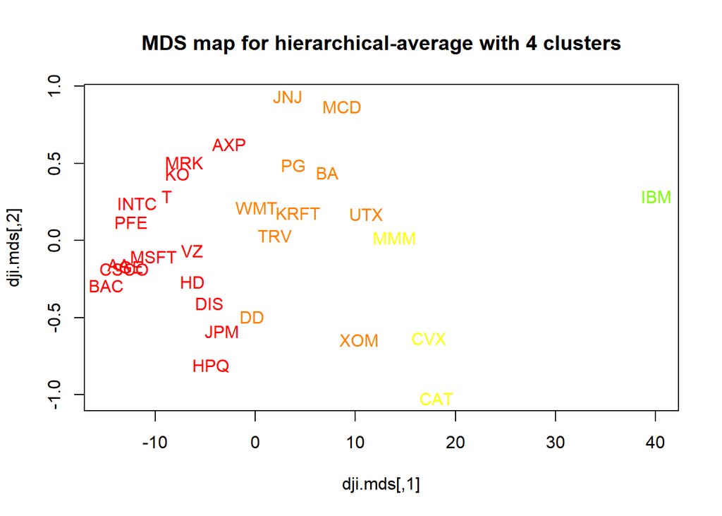

```r
dji.dist<-dist(data, method = 'euclidean')
dji.clust <- hclust(dji.dist, method = 'average')
hc5=cutree(dji.clust,4)
plot(dji.mds, type="n", main=paste0("MDS map for hierarchical-average with 4 clusters"))
text(dji.mds, rownames(dji.mds), col=rainbow(12)[hc5])
```

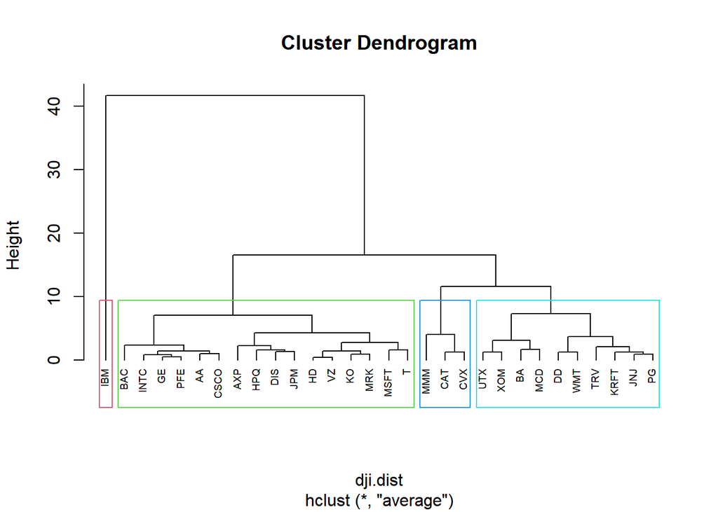

```r
plot(dji.clust,cex = 0.6, hang = -1)
rect.hclust(dji.clust, k = 4, border = 2:5)
```

[figure not shown]

```r
dji.dist<-dist(data, method = 'euclidean')
dji.clust <- hclust(dji.dist, method = 'average')
hc6=cutree(dji.clust,4)
plot(dji.mds, type="n", main=paste0("MDS map for hierarchical-average with 8 clusters"))
text(dji.mds, rownames(dji.mds), col=rainbow(12)[hc6])
```

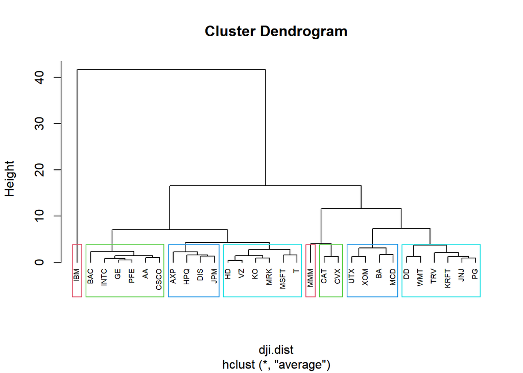

```r
plot(dji.clust,cex = 0.6, hang = -1)
rect.hclust(dji.clust, k = 8, border = 2:5)
```

# Problem 2.

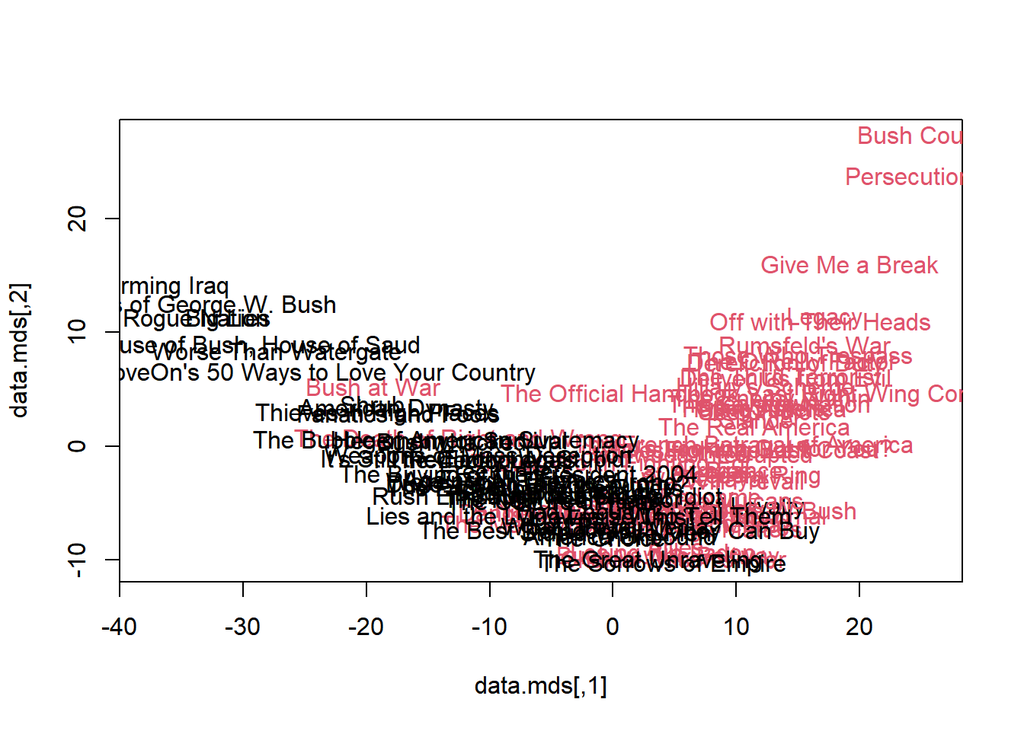

```r
library(plyr)
co_purchase <- read.csv('bookcopurchase.csv')
info <- read.csv('bookinfo.csv')
dataset<-na.omit(cbind(info,co_purchase))
bookdata = as.matrix(dataset[,5:ncol(dataset)])

data.dist = dist(as.matrix(bookdata)%*%t(bookdata))

b_name = dataset$name
class = mapvalues(dataset$Class,from=c("1", "3"),to=c("liberal","conservative") )
data.mds = cmdscale(data.dist)
col = mapvalues(dataset$Class,from=c("1", "3"),to=c("1","2"))
plot(data.mds, type = 'n')
text(data.mds,labels= b_name, col=col)
```

b.

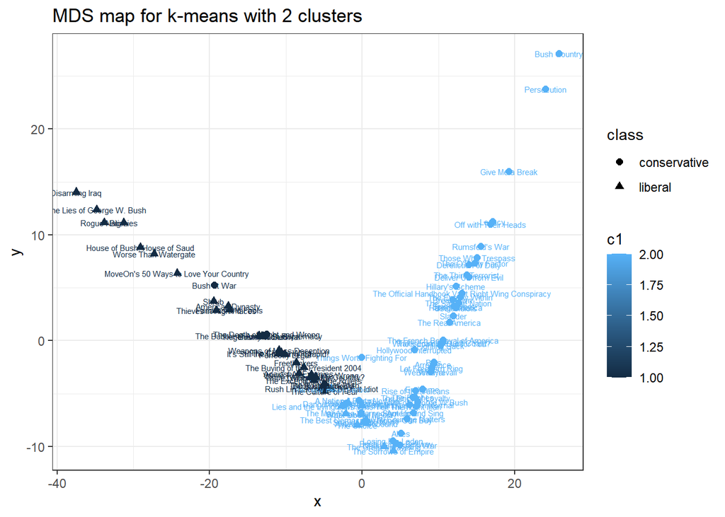

```r
set.seed(100)
data.c1=kmeans(bookdata,centers=2,nstart=10)
c1=data.c1$cluster
bookdata1 =
      data.frame(x=data.mds[,1],y=data.mds[,2],name=b_name,class=class,c1)
      p = ggplot(aes(x=x,y=y,shape=class,color=c1), data=bookdata1) +
      geom_point(size=2) +
      geom_text(aes(x=x,y=y,label=name), size=2)+
      ggtitle("MDS map for k-means with 2 clusters")
      print(p)
```

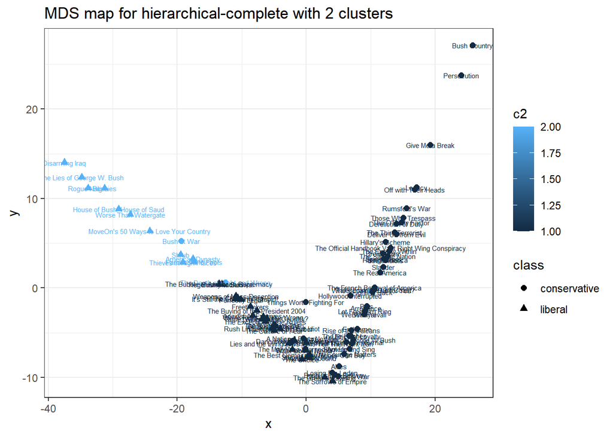

```r
set.seed(100)
hc1=hclust(data.dist,method='complete')
c2=cutree(hc1,2)
bookdata2 =
      data.frame(x=data.mds[,1],y=data.mds[,2],name=b_name,class=class,c2)
      p = ggplot(aes(x=x,y=y,shape=class,color=c2), data=bookdata2) +
      geom_point(size=2) +
      geom_text(aes(x=x,y=y,label=name), size=2) +
      ggtitle("MDS map for hierarchical-complete with 2 clusters")
      print(p)
```

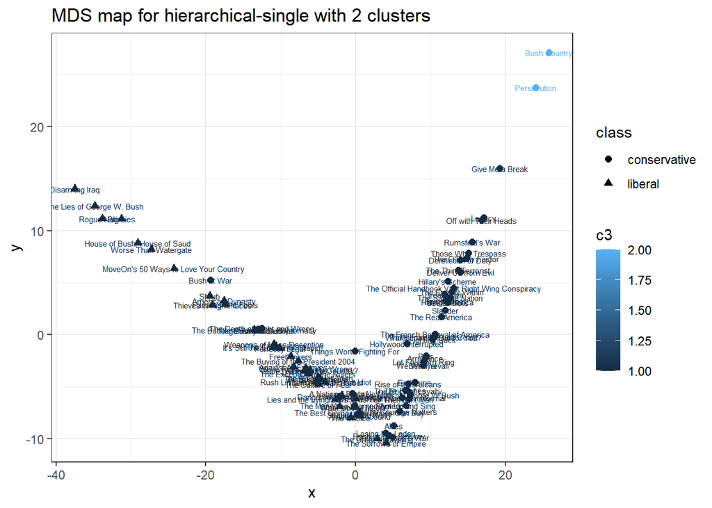

```r
set.seed(100)
hc2=hclust(data.dist,method='single')
c3=cutree(hc2,2)
bookdata3 =
      data.frame(x=data.mds[,1],y=data.mds[,2],name=b_name,class=class,c3)
      p = ggplot(aes(x=x,y=y,shape=class,color=c3), data=bookdata3) +
      geom_point(size=2) +
      geom_text(aes(x=x,y=y,label=name), size=2)+
      ggtitle("MDS map for hierarchical-single with 2 clusters")
      print(p)
```

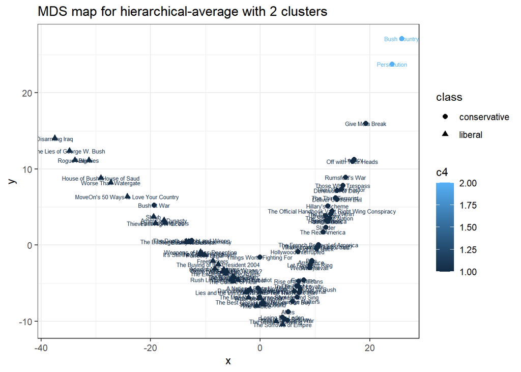

```r
set.seed(100)
hc3=hclust(data.dist,method='average')
c4=cutree(hc3,2)
bookdata4 =
      data.frame(x=data.mds[,1],y=data.mds[,2],name=b_name,class=class,c4)
      p = ggplot(aes(x=x,y=y,shape=class,color=c4), data=bookdata4) +
      geom_point(size=2) +
      geom_text(aes(x=x,y=y,label=name), size=2)+
      ggtitle("MDS map for hierarchical-average with 2 clusters")
      print(p)
```

```r
cluster.purity <- function(clusters, classes) {
  sum(apply(table(classes, clusters), 2, max)) / length(clusters)
}
cluster.entropy <- function(clusters,classes) {
  en <- function(x) {
    s = sum(x)
    sum(sapply(x/s, function(p) {if (p) -p*log2(p) else 0} ) )
  }
  M = table(classes, clusters)
  m = apply(M, 2, en)
  c = colSums(M) / sum(M)
  sum(m*c)
}

k_result=c(cluster.purity(c1,class),cluster.entropy(c1,class))
hc_result=c(cluster.purity(c2,class),cluster.entropy(c2,class))
hs_result=c(cluster.purity(c3,class),cluster.entropy(c3,class))
ha_result=c(cluster.purity(c4,class),cluster.entropy(c4,class))
summary <- cbind(k_result,hs_result,hc_result,ha_result)
colnames(summary) <- c("k-means","hclust-single","hclust-complete","hclust-average")
print(summary)
```

```
##        k-means hclust-single hclust-complete hclust-average
## [1,] 0.8369565     0.5326087       0.6304348      0.5326087
## [2,] 0.6090796     0.9768665       0.9237497      0.9768665
```

5. Based on the result of d, k-means has the highest purity and the lowest entropy and hclust-complet has the highest purity and the lowest entropy comparing to other two hclusting methods, so I will choose k-means and hclust-complete.